# Frontiers paper

Tara McAllister Byun and Heather Campbell

July 1, 2016

## Individual results: Effect sizes

Effect sizes representing change in $\hat{p}_{correct}$ for the treated variant, vocalic /r/, are reported for all participants in Table 3. The first column shows participants’ mean $\hat{p}_{correct}$ in the baseline period, averaged across all vocalic /r/ items from all baseline sessions. The second column shows the equivalent mean across the three midpoint sessions, and the third shows the three maintenance sessions. The next three columns report three standardized effect sizes: ES<sub>Phase1</sub> compares baseline versus midpoint scores, *ES<sub>Phase2</sub>* compares midpoint versus maintenance scores, and *ES<sub>All</sub>* compares baseline versus maintenance, reflecting overall gains across both phases of treatment. Participants are blocked by the order in which they received treatment (traditional-first or biofeedback-first). The effect sizes in Table 3 show a wide range of variability in overall response to treatment across individuals. Averaging effect sizes across all participants yields a mean of 4.38, suggesting that on average, participants’ response to the combined biofeedback and traditional treatment package was positive and exceeded the minimum value considered clinically significant. Individual patterns of response will be examined in detail in the next section.

|  | subject | bl1_m | bl1_sd | mp1_m | mp1_sd | mn1_m | mn1_sd | ESPhase1 | ESPhase2 | ESall |
| --- | --- | --- | --- | --- | --- | --- | --- | --- | --- | --- |
| 1 | Aiden | 46.03 | 7.43 | 87.31 | 3.02 | 78.01 | 4.46 | 7.28 | -2.44 | 5.22 |
| 2 | Bryce | 24.50 | 1.87 | 25.33 | 1.96 | 26.10 | 3.26 | 0.44 | 0.29 | 0.60 |
| 4 | Erica | 3.25 | 0.77 | 6.27 | 1.14 | 27.91 | 4.91 | 3.12 | 6.07 | 7.01 |
| 7 | Holly | 2.98 | 1.83 | 3.41 | 1.58 | 2.55 | 1.33 | 0.25 | -0.59 | -0.27 |
| 8 | Harper | 4.50 | 1.83 | 3.70 | 1.32 | 4.90 | 1.23 | -0.48 | 0.94 | 0.25 |
| 3 | Cooper | 3.51 | 0.49 | 4.96 | 0.98 | 4.24 | 0.41 | 2.00 | -0.96 | 1.60 |
| 5 | Ella | 66.04 | 7.24 | 92.47 | 2.54 | 87.08 | 3.19 | 4.34 | -1.87 | 3.40 |
| 6 | Gregory | 27.54 | 3.19 | 27.64 | 2.49 | 31.11 | 7.03 | 0.03 | 0.66 | 0.70 |
| 9 | Jason | 15.81 | 0.35 | 15.95 | 2.92 | 20.89 | 5.07 | 0.07 | 1.19 | 1.41 |
| 10 | Landon | 33.86 | 6.04 | 63.96 | 2.96 | 73.99 | 3.41 | 5.98 | 3.14 | 7.79 |
| 11 | Mason | 47.94 | 2.84 | 85.98 | 2.78 | 96.12 | 0.74 | 13.51 | 4.98 | 20.45 |

## Individual results: Visual inspection

The mean number of probe words on which $\hat{p}_{correct}$ scores are based was 14.98 (SD = 0.25) for pre- and post-treatment probes and 30 (SD = 0) for baseline and maintenance probes. The number of ratings collected in connection with a given probe session (i.e., the denominator in $\hat{p}_{correct}$) was roughly nine times the number of items in that probe and often was larger.

Figure 2 shows four participants for whom visual inspection offered strong evidence of a response to at least one type of treatment. Visual inspection of data from 10;2 year-old Aiden shows a large change in level between the baseline phase and all subsequent phases of treatment, with minimal overlap between observations in the baseline phase and any subsequent phase. This change occurred immediately after the initiation of treatment. Aiden’s progress in the first phase, which featured traditional articulatory treatment, yielded a large ES<sub>Phase1</sub> of 7.28. His performance declined to some extent in the second phase, which featured biofeedback treatment, yielding an *ES<sub>Phase2</sub>* of -2.44 from midpoint to maintenance. However, his performance still remained substantially above baseline levels, with a final *ES<sub>All</sub>* of 5.22.

Ella, age 13;8, also showed a sizable change in level between the baseline phase and all subsequent phases of the study. This change was evident in post-treatment word probes within the first three sessions of treatment; from the fourth session on, there was virtually no overlap of data points with the baseline phase. The first phase, which featured biofeedback treatment, yielded an *ES<sub>Phase1</sub>* of 4.34. Ella’s gains remained mostly stable through the second phase of treatment and the maintenance period, yielding an *ES<sub>All</sub>* of 3.4. Overlap with the baseline phase was minimal from the midpoint session on.

Participants Landon, age 9;6, and Mason, age 12;10, exhibited similar trajectories of progress, although Mason showed higher overall accuracy throughout the study. Like Ella, both boys began in the biofeedback treatment condition and began to show gains within the first three sessions of treatment; they sustained their gains during midpoint probes and made additional improvements in the second phase of treatment. They likewise showed no overlap between the baseline phase and data points in the midpoint phase, second phase of treatment, or maintenance phase. In Mason’s case, there also was very little overlap between the baseline phase and the first phase of treatment. For both boys, a larger effect size was calculated for the first phase of treatment, in which biofeedback was provided, although this could be attributed to a ceiling effect in Mason’s case. Large overall effect sizes of 7.79 and 20.45 were observed for Landon and Mason, respectively.

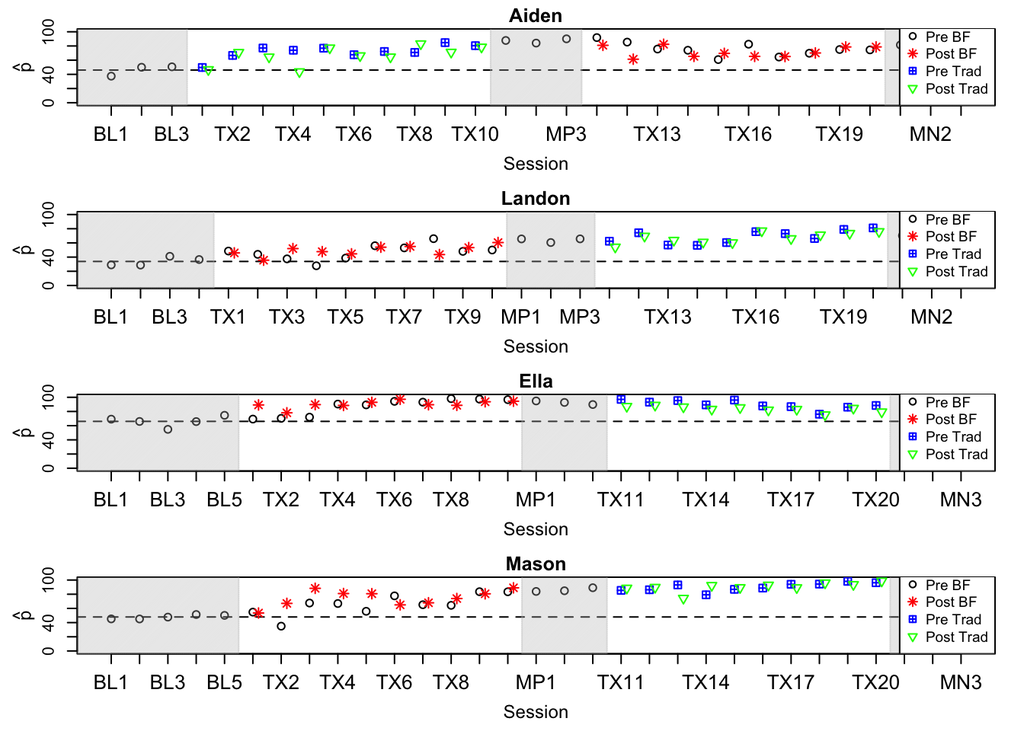

**Figure 2. Longitudinal plots of $\hat{p}_{correct}$ for participants with large positive effect sizes. Dashed line represents mean across baseline sessions. BL = Baseline, Tx = Treatment, MN = Maintenance.**

Figure 3 shows three participants for whom visual inspection offered moderate evidence of a response to at least one type of treatment. Erica, age 9;3, showed no visual evidence of improvement in the first phase, which featured traditional treatment. (An *ES<sub>Phase1</sub>* of 3.12 was computed for her, but given that the raw difference in means was only 3.02, this was judged to be an artifact of low variance during the baseline phase.) During the second phase of treatment, Erica showed a change in trend from a stable near-zero level of accuracy to a small but consistent increase. This effect is ambiguous to interpret, since it emerged only in the last three sessions of the study and thus could reflect a cumulative effect of treatment over the preceding two months. Interestingly, the rising trend that Erica exhibited in her last three sessions of treatment continued into the maintenance phase, suggesting that ongoing generalization gains might be anticipated. Her final effect size (*ES<sub>All</sub>*) of 7.01 reflected robust overall gains, although her scores in the maintenance phase remained well below ceiling-level accuracy.

Participant Jason, age 15;10, showed a trajectory that was in some ways a mirror image of Erica’s. Both visual inspection and effect size showed no meaningful change during the first phase of treatment, which featured biofeedback. He also showed no change throughout most of the second treatment phase, but in the final few sessions, his perceptually rated accuracy took on a distinct upward slope. Unlike Erica, his gains tended to affect post-test but not pre-test probes, and accuracy was not sustained throughout the maintenance period. This suggests more short-term learning that was not yet robustly transfering to other contexts. Accordingly, the effect sizes calculated using midpoint and maintenance probe data suggested a weaker effect of treatment than visual inspection of within-treatment data would suggest (*ES<sub>Phase1</sub>* 0.07; *ES<sub>Phase2</sub>* 1.19; *ES<sub>All</sub>* 1.41).

Participant Gregory, age 9;10, showed a small increase in the perceptually rated accuracy of rhotics produced during Phase 1, followed by a slightly larger increase during Phase 2. Ongoing overlap in data points between baseline and treatment phases prevents us from attaching a strong interpretation to these data, and gains were minimally sustained into the midpoint and maintenance probe intervals. All three effect sizes computed for Gregory fell short of the threshold to be considered clinically significant (*ES<sub>Phase1</sub>* 0.03; *ES<sub>Phase2</sub>* 0.66; *ES<sub>All</sub>* 0.7). On the other hand, Gregory’s accuracy during both phases of treatment was much more variable than at baseline. This suggested that he was engaging some degree of exploration of new strategies for rhotic production, although he had not yet stabilized a production pattern that would reliably yield a perceptually accurate rhotic sound.

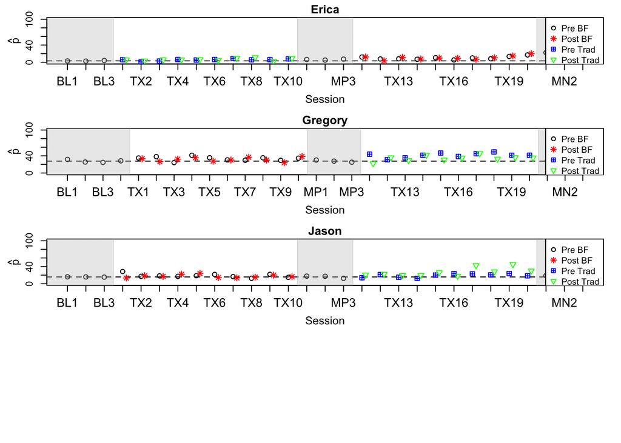

Finally, Figure 4 depicts the four participants for whom visual inspection of generalization probe data yielded no significant evidence of a response to either type of treatment. Three of these participants (Bryce, Holly, and Harper) began treatment in the traditional treatment condition, while one participant (Cooper) received treatment in the opposite order. Across all of these participants, visual inspection of perceptual rating data yields a consistent picture of minimal change across all phases of the study. Effect sizes are generally in accordance with visual inspection; an exception is Cooper’s *ES<sub>Phase1</sub>* of 2.0, but this value is inflated by minimal variance during the baseline phase. Note also that most participants in this group had near-zero perceptual accuracy ratings at baseline, contrasting with the more intermediate accuracy ratings given to participants in the other groups; we return to this topic in the discussion section.

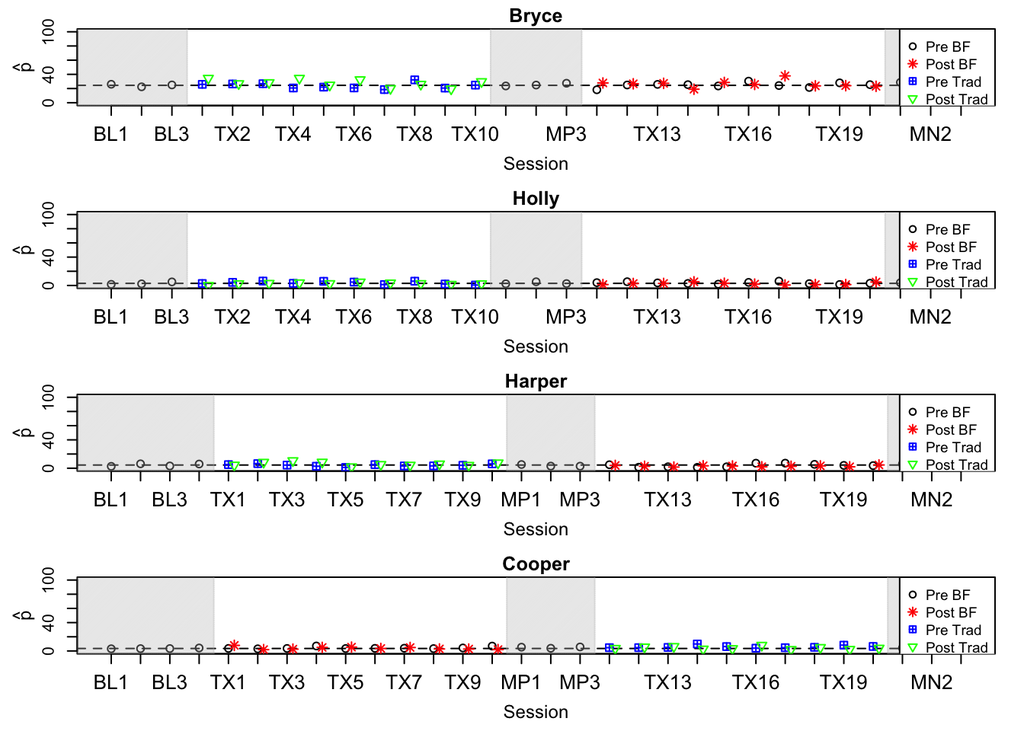

**Figure 4. Longitudinal plots of $\hat{p}_{correct}$ for participants with null or negative effect size. Dashed line represents mean across baseline sessions. BL = Baseline, Tx = Treatment, MN = Maintenance.**

## Across-subjects comparisons: Effect sizes

Although the primary focus of this single-subject experimental study is on within-subject changes, the counterbalanced design makes it possible to explore between-subjects effects as well. The boxplots in Figures 5-6 show the distribution of effect sizes observed when the data are partitioned in different ways. In Figure 5a, effect sizes associated with biofeedback treatment phases (*ES<sub>BF</sub>*) are compared against effect sizes from traditional treatment phases (*ES<sub>Trad</sub>*), independent of the order in which the two types of treatment were delivered. Figure 5b examines a possible order effect, comparing the distribution of *ES<sub>Phase1</sub>* versus *ES<sub>Phase2</sub>*, independent of the type of treatment delivered in each phase. Finally, Figure 6 considers a possible interaction between treatment type and order of treatment delivery: participants are partitioned into those who received biofeedback first versus traditional treatment first, and the distribution of effect sizes observed in each treatment condition is plotted.

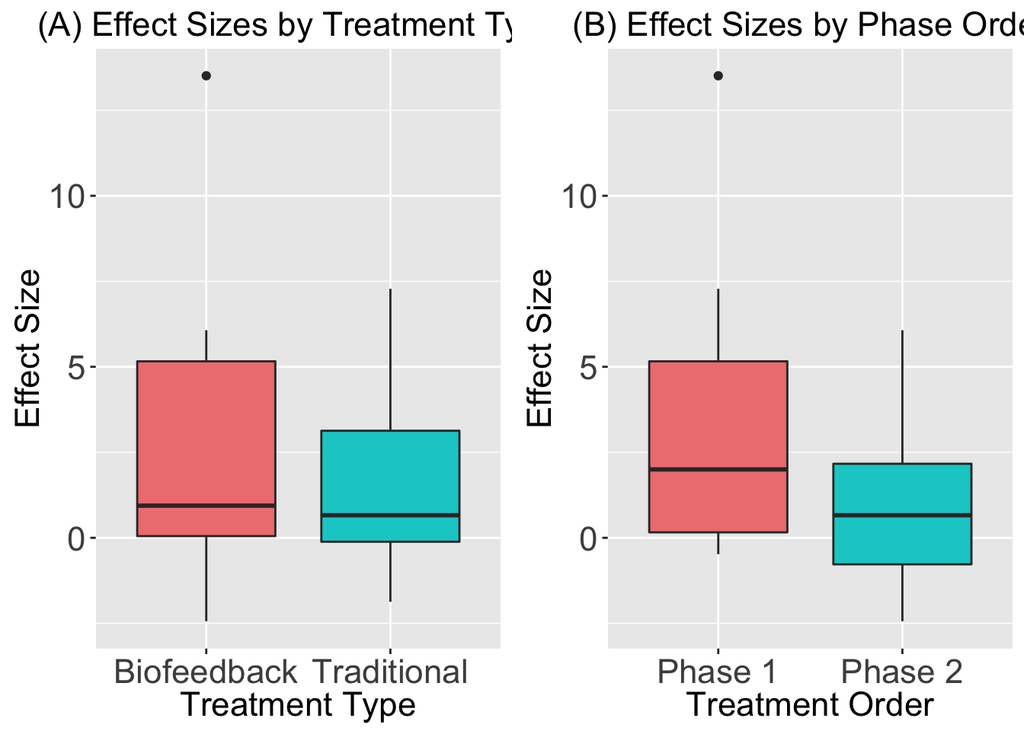

**Figure 5. Boxplots depicting the distribution of effect sizes observed in connection with (A) biofeedback versus traditional treatment, independent of phase order; (B) phase 1 versus phase 2 of treatment, independent of treatment type.**

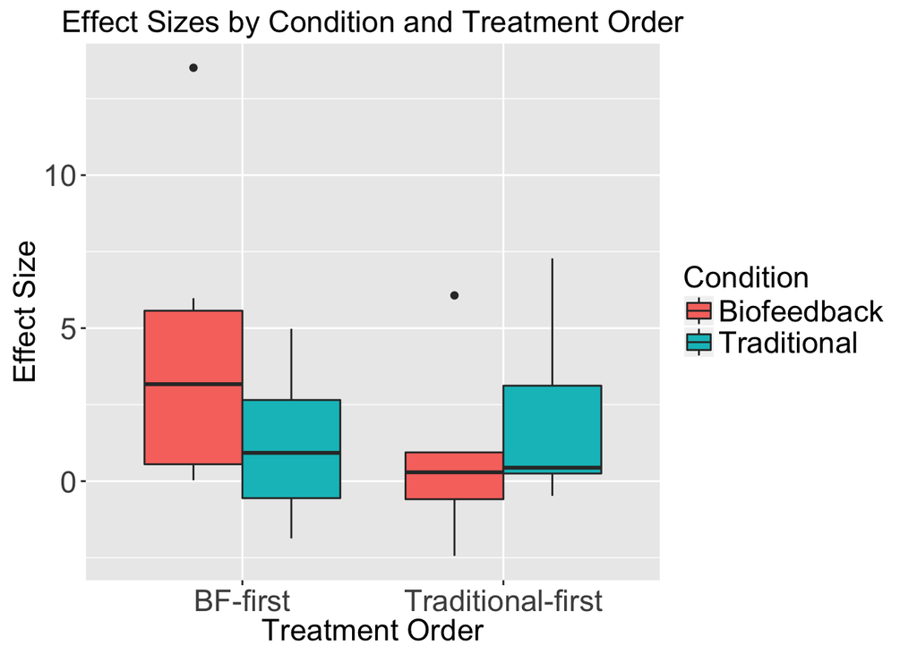

**Figure 6. Boxplots depicting the distribution of effect sizes observed in connection with biofeedback versus traditional treatment when biofeedback treatment was provided first, versus the opposite order.**

Figure 5a shows that the effect size distributions observed in biofeedback versus traditional phases of treatment are extensively overlapped and have very similar median values, although the interquartile range extends to somewhat higher effect sizes for biofeedback than traditional treatment. Figure 5b shows that effect sizes observed in the first phase of treatment tended to be larger than the second phase, although again there is considerable overlap between the interquartile ranges for the two distributions. Separation across phases and conditions becomes evident only when we examine the interaction between the two in Figure 6. Effect sizes observed in connection with biofeedback treatment were substantially larger when biofeedback was provided in Phase 1 versus Phase 2. Interestingly, the median effect size observed for traditional treatment was also slightly higher in the biofeedback-first condiiton, although the interquartile ranges overlap almost completely. Due to the small number of data points, hypothesis tests were not conducted on these comparisons of effect sizes across conditions. Instead, the logistic mixed model reported in the next section will examine these effects and their interactions in greater detail.

## Across-subjects comparisons: Mixed logistic model

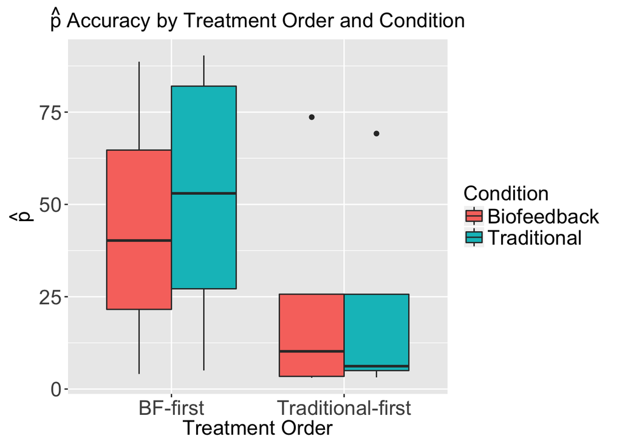

The effect sizes discussed in the preceding sections reflect participants’ long-term or generalization gains in response to treatment. However, recall that some participants made short-term gains that were evident on post-test probes during treatment, but which were not sustained into the midpoint or maintenance phases (see, e.g., Figure 3). To take these gains into consideration, the logistic mixed model was fitted over all data points from pre- and post-treatment probes elicited during the two phases of treatment. For this analysis, we used an uncollapsed data set in which each data point was a single listener’s rating of a single token. The binary rating (correct/incorrect) served as the dependent variable. Random intercepts were included to reflect the fact that data points were nested within subjects, items, and raters. Fixed effects including treatment condition (biofeedback versus traditional) and order of treatment delivery (biofeedback-first versus traditional-first) were examined. Model selection was performed using likelihood ratio tests, and only those effects and interactions that yielded a significant difference in likelihood relative to a reduced model were retained. The final model included the interaction between treatment condition and order of treatment delivery, as well as a by-subject random slope for the effect of treatment condition.

In the logistic mixed model described above, treatment condition (TRAD versus BF) was not a significant predictor of rhotic production accuracy (*$\beta$* = -0.10, *SE* = 0.23, *p* = 0.65), nor was order of treatment delivery (*$\beta$* = 1.62, *SE* = 1.14, *p* = 0.15). However, the interaction between treatment type and treatment order was significant (*$\beta$* = 0.67, *SE* = 0.30, *p* = 0.03). This interaction can be visualized in Figure 7, which plots accuracy in within-treatment probes (pre- and post-probes) during both biofeedback and traditional treatment conditions; they are pooled across subjects but partitioned by the order of treatment application (BF-first or TRAD-first). Figure 7 shows that the overall highest accuracy was observed during a phase of traditional treatment that came after a phase of biofeedback treatment. The second-highest accuracy was observed in an initial phase of biofeedback treatment. (Figure 7 shows that accuracy scores tended to be higher in the BF-first order than the TRAD-first order, although this effect was not significant.) Complete regression results are reported in On-line Supplement A.